# 神经网络和深度学习作业一：实验报告

## 从零开始构建三层神经网络分类器，实现图像分类

### 23210980037樊陈卓

```python
# 导入必要的模块
import os
import gzip
import numpy as np
import re

# 设置随机数种子
np.random.seed(42)
import sys
import json
import matplotlib.pyplot as plt
```

## 1.查看数据集构成

使用fashion mnist定义的dataloader方法

```python
def load_mnist(path, kind='train'):
    """Load MNIST data from `path`"""
    labels_path = os.path.join(path,
                               '%s-labels-idx1-ubyte.gz'
                               % kind)
    images_path = os.path.join(path,
                               '%s-images-idx3-ubyte.gz'
                               % kind)

    with gzip.open(labels_path, 'rb') as lbpath:
        labels = np.frombuffer(lbpath.read(), dtype=np.uint8,
                               offset=8)

    with gzip.open(images_path, 'rb') as imgpath:
        images = np.frombuffer(imgpath.read(), dtype=np.uint8,
                               offset=16).reshape(len(labels), 784)

    return images, labels
```

```python
X_train, y_train = load_mnist('dataset', kind='train')
X_test, y_test = load_mnist('dataset', kind='t10k')
```

```python
img = np.array(X_test[0]).reshape((28, 28))
```

[figure not shown]

```python
plt.imshow(img, cmap='gray')
```

可以看到是这是一双鞋子的数据

```python
objects = {0: 'T-shirt/top',
           1: 'Trouser',
           2: 'Pullover',
           3: 'Dress',
           4: 'Coat',
           5: 'Sandal',
           6: 'Shirt',
           7: 'Sneaker',
           8: 'Bag',
           9: 'Ankle boot'}
```

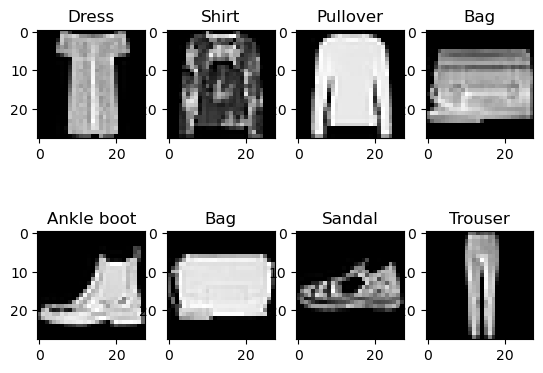

```python
f, axes = plt.subplots(2, 4)
for row in axes:
    for axe in row:
        index = np.random.randint(10000)
        img = np.array(X_train[index]).reshape((28, 28))
        obj= y_train[index]
        axe.imshow(img, cmap='gray')
        axe.set_title(objects[obj])
```

实验发现这个数据集的结构，x里是一堆28*28的灰度图片数据，y则是对应的label标签，只不过是0-9来代替'T-shirt/top'-'Ankle boot'

因此可以根据这个代码实现一个dataloader，需要对读取的图片数据/255进行归一化处理

## 2.网络结构设计

绘图来源 ：https://alexlenail.me/NN-SVG/LeNet.html

最终设计为三层网络，接受 784 个输入特征，有三个隐藏层，分别具有256、32和10个神经元，最终输出一个分类结果

[figure not shown]

## 3.超参数搜索

进行超参数搜索，以优化神经网络模型的性能。尝试不同的参数组合，并评估它们在训练数据集上的表现，以找到最佳的超参数组合。

将尝试的超参数包括：

- 第一个隐藏层的大小（hidden_size_1），我们将尝试128和256两种选项。
- 第二个隐藏层的大小（hidden_size_2），我们将尝试64和32两种选项。
- 学习率（lr），我们将尝试0.01、0.05和0.1三种选项。
- 正则化系数（ld），我们将尝试0.001和0.005两种选项。

将使用交叉验证技术来评估每个参数组合的性能，并选择在验证集上表现最佳的参数组合作为最终模型的超参数。通过这种方式，我们可以更好地调整模型，以获得更好的性能并提高泛化能力。

在具体的参数列表内，可以看到最高的准确率是 0.857，对应的超参数组合是：

{

```
"hidden_size_1": 256,

"hidden_size_2": 32,

"lr": 0.05,

"ld": 0.001,

"input_dim": 784,

"output_dim": 10,

"activation_1": "relu",

"activation_2": "relu",

"activation_3": "softmax",

"decay_rate": 0.95,

"decay_step": 6000
```

## 4.根据超参数训练模型

运行代码中的 python train.py 命令（需要修改参数），将使用最优的超参数组合在整个训练数据集上训练模型

## 5.测试模型

在测试测试结果为Test Loss: 0.5085 | Test Acc: 0.8537 | Checkpoint: models/model_epoch_100.pkl ，还是具有一定的泛化能力的

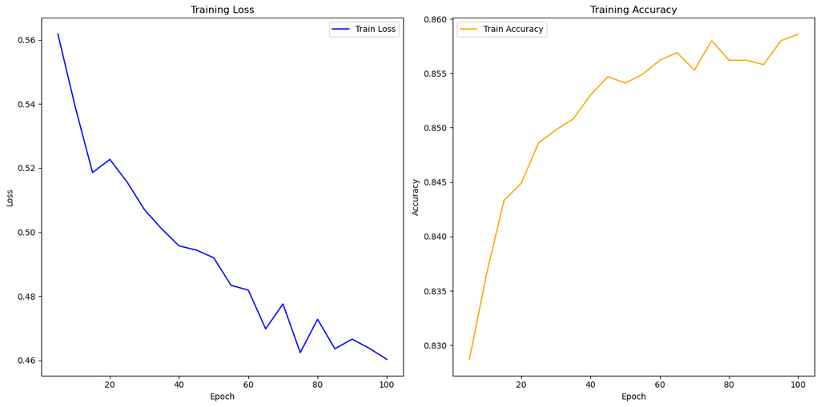

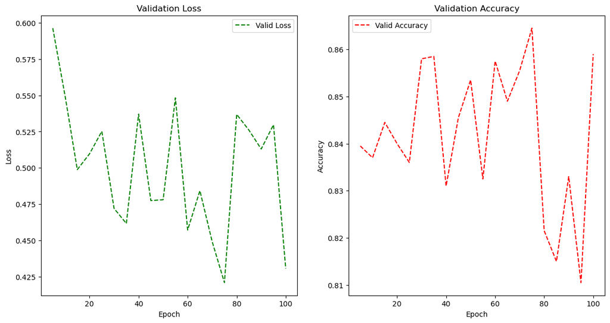

```python
# 初始化列表以存储数据
epochs = []
train_losses = []
train_accs = []
valid_losses = []
valid_accs = []

# 正则表达式，用于从每行中提取epoch、train_loss、train_acc、valid_loss和valid_acc
pattern = re.compile(r'Epoch (\d+) \|.*learning rate: (\S+)\s+\| Train Loss: (\S+) \| Train Acc: (\S+) \|.*Valid Loss: (\S+) \| Valid Acc: (\S+)')

# 打开文件并逐行读取
with open('.\\logs\\train_log.txt', 'r') as file:
    for line in file:
        match = pattern.search(line)
        if match:
            epoch = int(match.group(1))
            epochs.append(epoch)

            train_loss = float(match.group(3))
            train_losses.append(train_loss)

            train_acc = float(match.group(4))
            train_accs.append(train_acc)

            valid_loss = float(match.group(5)) if match.group(5) else None
            valid_losses.append(valid_loss)

            valid_acc = float(match.group(6)) if match.group(6) else None
            valid_accs.append(valid_acc)

# 绘图
plt.figure(figsize=(14, 7))

# 训练损失
plt.subplot(1, 2, 1)
plt.plot(epochs, train_losses, label='Train Loss', color='blue')
plt.xlabel('Epoch')
plt.ylabel('Loss')
plt.title('Training Loss')
plt.legend()

# 训练准确率
plt.subplot(1, 2, 2)
plt.plot(epochs, train_accs, label='Train Accuracy', color='orange')
plt.xlabel('Epoch')
plt.ylabel('Accuracy')
plt.title('Training Accuracy')
plt.legend()

# 显示图表
plt.tight_layout()
plt.show()

#
plt.figure(figsize=(14, 7))

# 验证损失
plt.subplot(1, 2, 1)
plt.plot(epochs, valid_losses, label='Valid Loss', linestyle='--', color='green')
plt.xlabel('Epoch')
plt.ylabel('Loss')
plt.title('Validation Loss')
plt.legend()

# 验证准确率
plt.subplot(1, 2, 2)
plt.plot(epochs, valid_accs, label='Valid Accuracy', linestyle='--', color='red')
plt.xlabel('Epoch')
plt.ylabel('Accuracy')
plt.title('Validation Accuracy')
plt.legend()

# plt.tight_layout()
# plt.show()
```

在训练集上测试结果图上面2图，可以看到随着训练次数增加训练准确率有所上升，损失也持续下降，在验证集上的测试结果并不理想，准确率有所波动，但保持在0.84上下

## 模型可视化

模型各层的权重分布和热力图见下

第一层：

[figure not shown]

第二层：

[figure not shown]

第三层：

[figure not shown]

## 其他

项目地址：https://github.com/JordanGithub7/hw1

模型地址：

链接：https://pan.baidu.com/s/17dCa8N8Q-q6HuuExGzDBEA?pwd=0jv6 提取码：0jv6 --来自百度网盘超级会员V5的分享